# How to inspect your data in an R Notebook

Given a data set, it is very useful to be able to carry out exploratory data analysis on it. This is where we want to see what we have got, what it looks like, whether any data values are missing, and so on.

Let’s look first at the `airquality` data set that is built into R

When we load this into R, we get a data frame called airquality

```r
data(airquality)
class(airquality)
```

```
## [1] "data.frame"
```

In the case of a data set that comes built-in to R, like airquality, we can find out what it contains by using the usual help facility within R, whereby we type a quation mark in the console, followed by the name of the thing we want help about:

```r
?airquality
```

The help information then appears in the Help window in the bottom right-hand pane of RStudio.

In general, where our data does not come from within R, we cannot do this. We can, however, so several things that give us an idea of our data.

### str()

We can use the `str()`to find out how many rows and columns there are, what kinds of data the columns contain, and what each column is called:

```r
str(airquality)
```

```
## 'data.frame':    153 obs. of  6 variables:
##  $ Ozone  : int  41 36 12 18 NA 28 23 19 8 NA ...
##  $ Solar.R: int  190 118 149 313 NA NA 299 99 19 194 ...
##  $ Wind   : num  7.4 8 12.6 11.5 14.3 14.9 8.6 13.8 20.1 8.6 ...
##  $ Temp   : int  67 72 74 62 56 66 65 59 61 69 ...
##  $ Month  : int  5 5 5 5 5 5 5 5 5 5 ...
##  $ Day    : int  1 2 3 4 5 6 7 8 9 10 ...
```

### summary()

To get summary statistics on each variable, we can use summary(). For each variable, this tells us the minimum and maximum values, the mean, the median and the first and third quartile values.

```r
summary(airquality)
```

```
##      Ozone           Solar.R           Wind             Temp
##  Min.   :  1.00   Min.   :  7.0   Min.   : 1.700   Min.   :56.00
##  1st Qu.: 18.00   1st Qu.:115.8   1st Qu.: 7.400   1st Qu.:72.00
##  Median : 31.50   Median :205.0   Median : 9.700   Median :79.00
##  Mean   : 42.13   Mean   :185.9   Mean   : 9.958   Mean   :77.88
##  3rd Qu.: 63.25   3rd Qu.:258.8   3rd Qu.:11.500   3rd Qu.:85.00
##  Max.   :168.00   Max.   :334.0   Max.   :20.700   Max.   :97.00
##  NA's   :37       NA's   :7
##      Month            Day
##  Min.   :5.000   Min.   : 1.0
##  1st Qu.:6.000   1st Qu.: 8.0
##  Median :7.000   Median :16.0
##  Mean   :6.993   Mean   :15.8
##  3rd Qu.:8.000   3rd Qu.:23.0
##  Max.   :9.000   Max.   :31.0
##
```

### Missing Values - NAs

Note that for the `Ozone` and `Solar.R` variables a number of ’NA’s are listed. These are missing values, which are a very common feature of real data sets. In a typical data analysis, you need to identify whether these are present, and if so, what to do about them. In many cases, R functions contain an additional optional argument `na.rm=TRUE` that allows NAs to be ignored:

Try calculating the mean of the Ozone column:

```r
mean(airquality$Ozone)
```

```
## [1] NA
```

It does not work because of the NA values within the column. However, if we ignore these using the `na.rm=TRUE` argument, all is well:

```r
mean(airquality$Ozone, na.rm=TRUE)
```

```
## [1] 42.12931
```

### head() and tail()

Sometimes it is helpful to actually see a few rows of data. The `head()` and ’tail()` commands reveal the first and last few lines of data, respectively.

```r
head(airquality)
```

|  | Ozone | Solar.R | Wind | Temp | Month | Day |
| --- | --- | --- | --- | --- | --- | --- |
| 1 | 41 | 190 | 7.4 | 67 | 5 | 1 |
| 2 | 36 | 118 | 8.0 | 72 | 5 | 2 |
| 3 | 12 | 149 | 12.6 | 74 | 5 | 3 |
| 4 | 18 | 313 | 11.5 | 62 | 5 | 4 |
| 5 | NA | NA | 14.3 | 56 | 5 | 5 |
| 6 | 28 | NA | 14.9 | 66 | 5 | 6 |

```r
tail(airquality)
```

|  | Ozone | Solar.R | Wind | Temp | Month | Day |
| --- | --- | --- | --- | --- | --- | --- |
| 148 | 14 | 20 | 16.6 | 63 | 9 | 25 |
| 149 | 30 | 193 | 6.9 | 70 | 9 | 26 |
| 150 | NA | 145 | 13.2 | 77 | 9 | 27 |
| 151 | 14 | 191 | 14.3 | 75 | 9 | 28 |
| 152 | 18 | 131 | 8.0 | 76 | 9 | 29 |
| 153 | 20 | 223 | 11.5 | 68 | 9 | 30 |

The default is to reveal 6 rows. If you want see a different number, then you can specify the number of rows to be shown, for example: `head(airquality,10)`.

### Factors - categorical variables

Let’s convert the month column to a *factor*. That is R’s term for a categorical variable. While we are at it, let us give the *levels* of this factor, which are the different values it takes, descriptive labels. These we will take from the built-in R constant `months.abb`, which is a vector of abbreviated names for each month of the year. Lastly we will tell R that these levels are ‘ordered’, in the sense that June comes after May, etc (whereas, in another context, apples do not come fater lemons, say)

```r
airquality$Month <- factor(airquality$Month, levels=5:9, labels=month.abb[5:9], ordered=TRUE)
```

For the days column, it might be useful to know what day of the week each observation takes place on, since that might help us establish a link between ozone concentration and ctraffic levels, for example.

To do this, we can create a new column called `dow`, which first has the numbers 1:7 repeating, with ‘1’ indication a Monday. Since the first observation tok place on 1st May 1973, which was a Tuesday, we can achieve our aim like this:

```r
airquality$dow<-rep_len(c(2,3,4,5,6,7,1),153)
```

This replicates the sequence 2,3,4,5,6,7,1 until the total length is 153 rows. See `?rep` for further help on this.

Now we can convert this to a labelled, ordered factor, just like we did for the Month column:

```r
airquality$dow <- factor(airquality$dow, levels=1:7, labels=c("Mon","Tue","Wed","Thu","Fri","Sat","Sun"), ordered=TRUE)
```

Unlike with the months, there is no built in vector of abbreviations of the days of the week, so we have had to write our own.

### Box plot and strip plot

We can plot the ozone level, split by month or day of the week, using either a `boxplot`

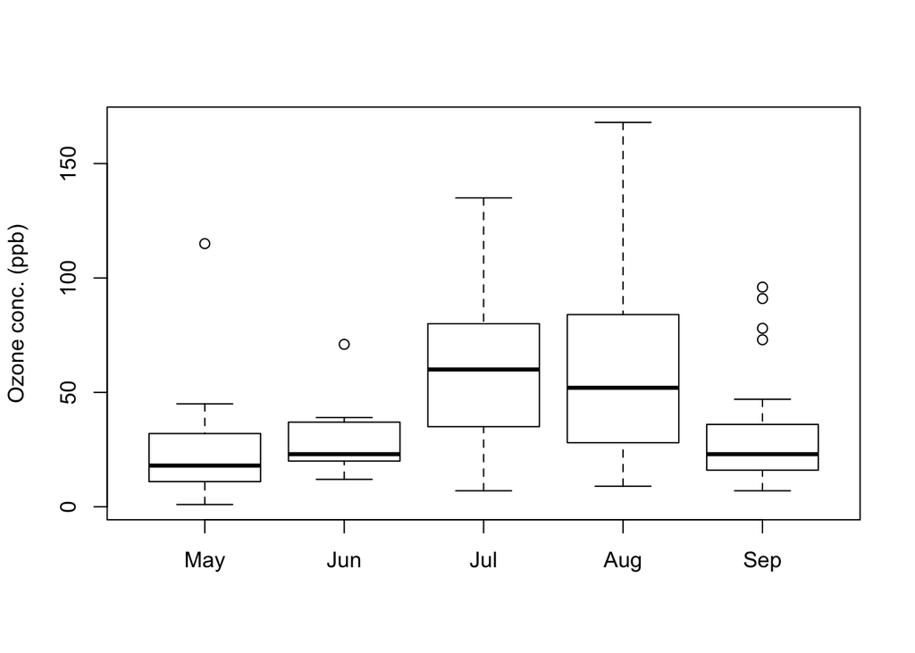

```r
boxplot(Ozone ~ Month,data=airquality,ylab="Ozone conc. (ppb)")
```

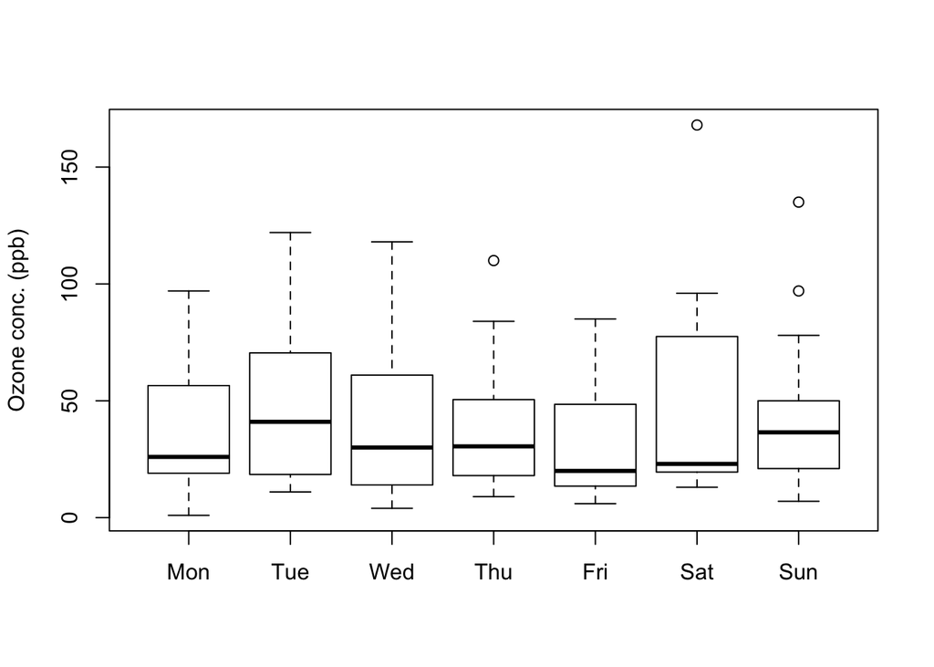

```r
boxplot(Ozone ~ dow,data=airquality,ylab="Ozone conc. (ppb)")
```

or, here where there are not many data points, we could also usefully use a `stripplot`, from the `lattice` package.

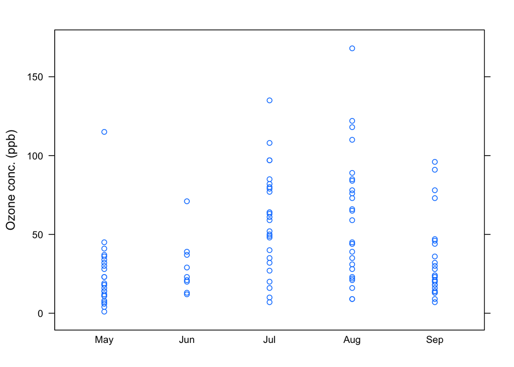

```r
library(lattice)
stripplot(Ozone~ Month,data=airquality,ylab="Ozone conc. (ppb)")
```

### Histogram

We can do a histogram, for example of the wind speed values.

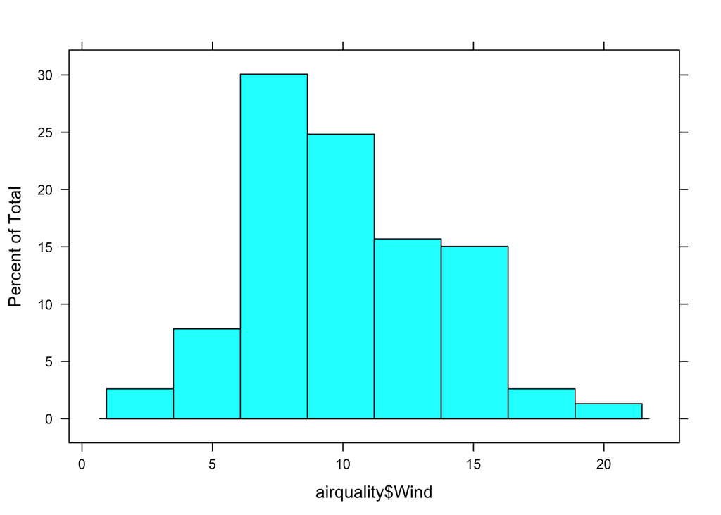

```r
histogram(airquality$Wind)
```

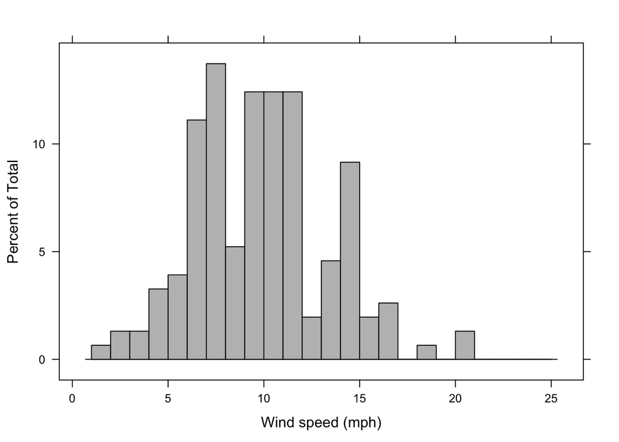

```r
histogram(airquality$Wind,breaks=c(1:25),xlab="Wind speed (mph)",col="grey")
```